# 01_all_cells_clustering_annotation

Stephanie Hickey

2026-06-15

#### Lab: Weiming Li

#### Project: BCC125_sea_lamprey_scRNA

```r
library(tidyverse)
library(SingleCellExperiment)
library(scater)
library(scran)
library(patchwork)
library(RColorBrewer)
library(readxl)
library(monocle3)
library(batchelor)
library(DT)
library(rtracklayer)
library(BiocSingular)
library(ggnewscale)
source(paste0(params$project_dir, "/src/scRNA_seq_functions.R"))
```

```r
results_dir = paste0(params$project_dir, "/results/20260615")
data_dir    = paste0(params$project_dir, "/data")
```

# Collect individual samples into one object

```r
sample_dirs  = list.dirs(data_dir, full.names = TRUE, recursive = FALSE)
sample_names = basename(sample_dirs)

cds_list = list()
for (i in 1:length(sample_dirs)) {
  cds_list[[i]] = readRDS(paste0(sample_dirs[i], "/", sample_names[i],
                                  "_cds_mito_filter.Rds"))
}
names(cds_list) = sample_names

all.sce = list()
for (cds in names(cds_list)) {
  raw_counts          = counts(cds_list[[cds]])
  all.sce[[cds]]      = SingleCellExperiment(list(counts = raw_counts),
                                              colData = cds_list[[cds]]@colData)
  all.sce[[cds]]@colData$sample = cds
}

all.sce  <- lapply(all.sce, logNormCounts)
all.dec  <- lapply(all.sce, modelGeneVar)
all.hvgs <- lapply(all.dec, getTopHVGs, prop = 0.1)
all.sce  <- mapply(FUN = runPCA, x = all.sce, subset_row = all.hvgs)
saveRDS(all.sce, file = paste0(results_dir, "/all.sce.Rds"))
```

# Sample summary table

```r
df_list = list()
for (samp in names(all.sce)) {
  ncells     = ncol(all.sce[[samp]])
  med_counts = round(median(colData(all.sce[[samp]])$sum))
  med_genes  = round(median(colData(all.sce[[samp]])$detected))
  med_mito   = round(median(colData(all.sce[[samp]])$subsets_Mito_percent), digits = 2)

  df_list[[samp]] = data.frame(Sample                 = samp,
                                nCells                 = ncells,
                                medianCounts           = med_counts,
                                medianGenesDetected    = med_genes,
                                medianPercentMitoReads = med_mito)
}

df_all = do.call(rbind, df_list)
write.csv(df_all, file = paste0(results_dir, "/median_stats.csv"))
datatable(df_all, rownames = FALSE)
```

| Sample | nCells | medianCounts | medianGenesDetected | medianPercentMitoReads |
| --- | --- | --- | --- | --- |
| TF_C00004337 | 13803 | 6066 | 1287 | 0.67 |
| TM_C00004374 | 18324 | 10532 | 2141 | 2.19 |
| UND1_C00004336 | 17186 | 5721 | 1366 | 1.3 |
| UND2_C00004362 | 17454 | 6396 | 1431 | 1.29 |

# Merge samples, removing batch effect

```r
universe     <- Reduce(intersect, lapply(all.sce, rownames))
all.sce2     <- lapply(all.sce, "[", i = universe,)
all.dec2     <- lapply(all.dec, "[", i = universe,)
normed.sce   <- do.call(multiBatchNorm, all.sce2)
combined.dec <- do.call(combineVar, all.dec2)
combined.hvg <- getTopHVGs(combined.dec, n = 5000)

set.seed(1)
merged.sce <- do.call(fastMNN, c(normed.sce,
    list(subset.row = combined.hvg, BSPARAM = RandomParam())))

set.seed(1)
g <- buildSNNGraph(merged.sce, use.dimred = "corrected", k = 30)
set.seed(1)
colLabels(merged.sce) <- factor(igraph::cluster_louvain(g)$membership)

set.seed(1)
merged.sce <- runUMAP(merged.sce, dimred = "corrected")
set.seed(1)
merged.sce <- runTSNE(merged.sce, dimred = "corrected")

saveRDS(merged.sce, file = paste0(results_dir, "/merged.sce.Rds"))
```

The plot below shows the merged data in TSNE space separated by sample.

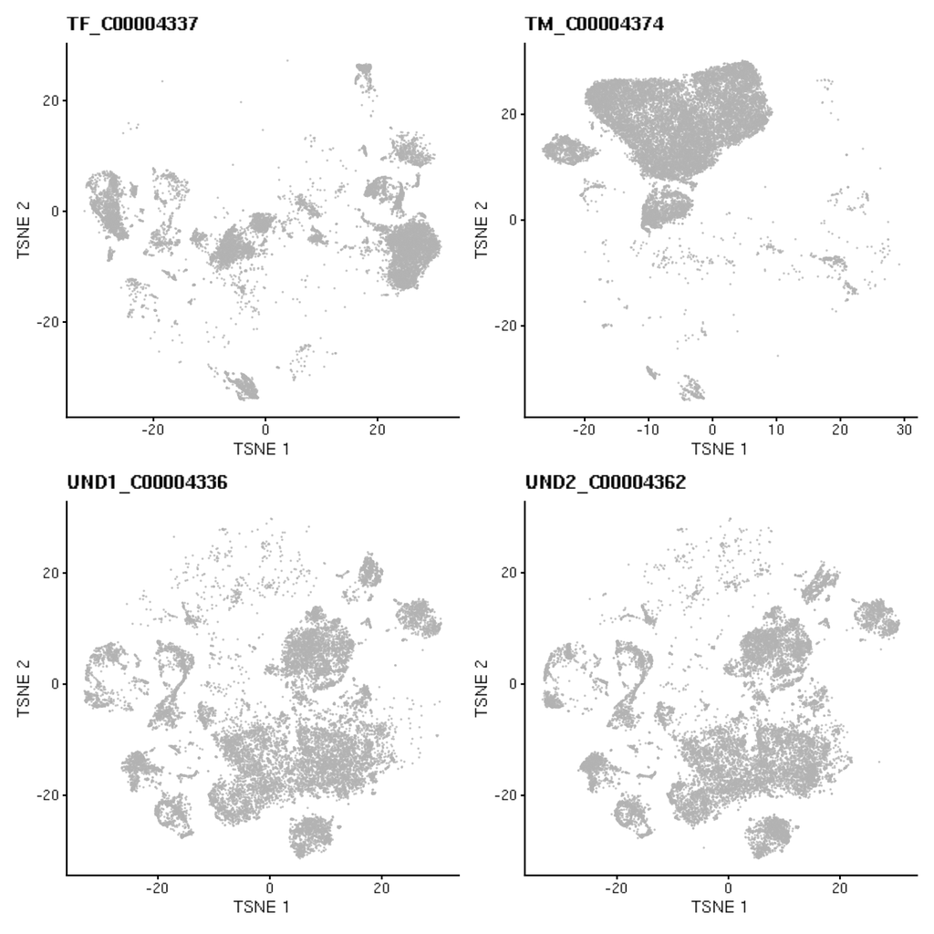

```r
p <- lapply(unique(merged.sce$batch), function(f) {
  sce.f = merged.sce[, which(merged.sce$batch == f)]
  plotTSNE(sce.f, point_size = .05) + ggtitle(f)
})
wrap_plots(p, ncol = 2)
```

Clusters identified in batch-corrected expression space.

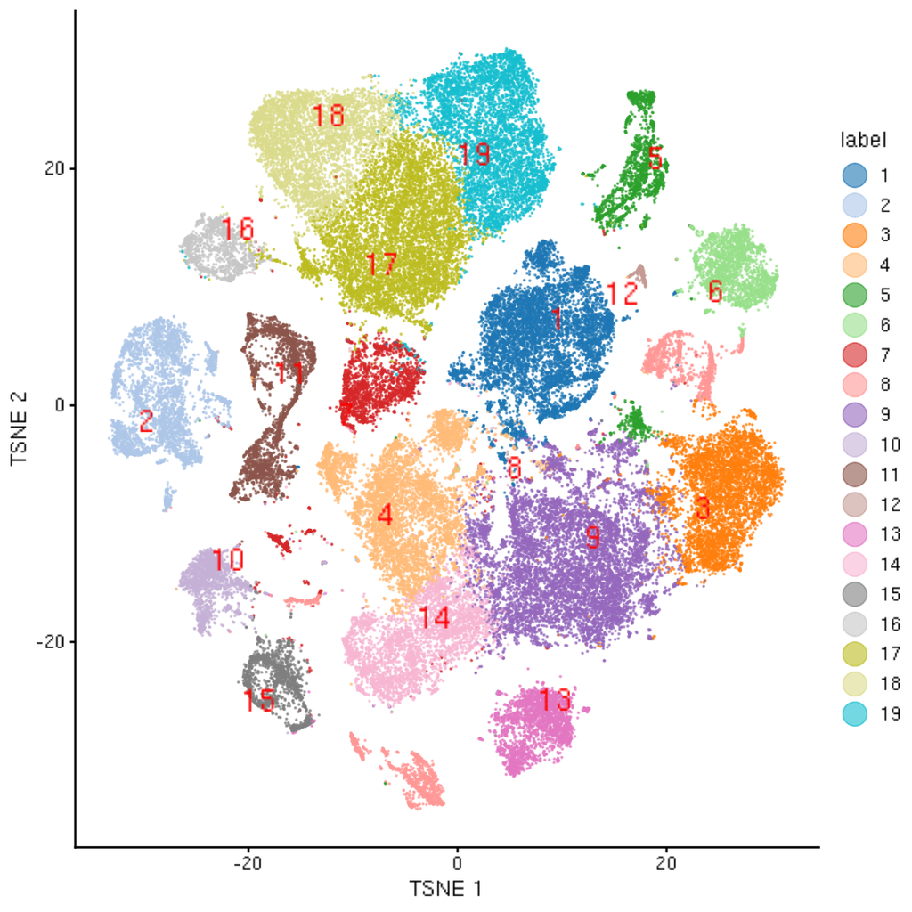

```r
plotTSNE(merged.sce, colour_by = "label", text_by = "label",
         text_colour = "red", point_size = .05) +
  guides(color = guide_legend(override.aes = list(size = 5)))
```

```r
ggsave(file = paste0(results_dir, "/all_cells_tsne.png"))
```

Proportion of cells from each sample within each cluster.

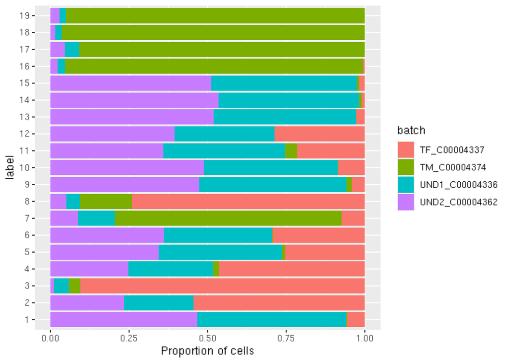

```r
meta_df = as.data.frame(colData(merged.sce))

sample_tally = meta_df %>%
  group_by(label, batch) %>%
  tally()

ggplot(sample_tally, aes(fill = batch, y = label, x = n)) +
  geom_bar(position = "fill", stat = "identity") +
  xlab("Proportion of cells")
```

```r
# build uncorrected combined SCE and monocle CDS for downstream plotting
all.dec  <- lapply(all.sce, modelGeneVar)
universe <- Reduce(intersect, lapply(all.sce, rownames))
all.sce2 <- lapply(all.sce, "[", i = universe,)
all.dec2 <- lapply(all.dec, "[", i = universe,)

all.sce2 <- lapply(all.sce2, function(x) {
  colData(x)    <- colData(x)[, "sample", drop = FALSE]
  reducedDims(x) <- list()
  rowData(x)    <- rowData(x)[, character(0)]
  x
})

combined.sce <- do.call(cbind, all.sce2)
saveRDS(combined.sce, file = paste0(results_dir, "/combined.sce.Rds"))

merged.cds <- new_cell_data_set(counts(combined.sce),
                                cell_metadata = merged.sce@colData)
reducedDims(merged.cds)$UMAP <- reducedDims(merged.sce)$UMAP
reducedDims(merged.cds)$tSNE <- reducedDims(merged.sce)$TSNE
rowData(merged.cds)$gene_short_name <- row.names(merged.cds)

saveRDS(merged.cds, file = paste0(results_dir, "/merged.cds.Rds"))
```

## Gene descriptions from Wang et al. and the kPetMar1.pri gtf

Summarized from [Wang et al, 2024](https://www.nature.com/articles/s41467-024-55019-x#Sec16): LOC IDs are re-annotated to human gene symbols via BLAST; genes with human matches are UPPERCASE, others lowercase.

```r
gene_description =
  read_excel(paste0(data_dir, "/41467_2024_55019_MOESM3_ESM.xlsx"), skip = 1) %>%
  dplyr::rename(WangGeneID = "CountMatrix_GeneID",
                Gene        = "NCBI_GTF_GENEID",
                description = "NCBI_GTF_ProteinInfo") %>%
  dplyr::select(Gene, WangGeneID, description) %>%
  filter(!is.na(Gene)) %>%
  filter(!WangGeneID %in% c("LOC116945425.1", "S100A1.1"))

gtf = as.data.frame(readGFF("/mnt/research/bioinformaticsCore/shared/Genomes/Petromyzon_marinus/GCF_010993605.1_kPetMar1.pri_genomic.gtf"))

gtf_filt =
  gtf %>%
  filter(gbkey %in% c("mRNA", "misc_RNA", "ncRNA", "tRNA", "rRNA")) %>%
  mutate(product = gsub(", transcript variant.*", "", product)) %>%
  dplyr::select(gene_id, product) %>%
  distinct() %>%
  dplyr::rename(Gene = "gene_id", description = "product") %>%
  mutate(WangGeneID = Gene)

notWang      = gtf_filt$Gene[!gtf_filt$Gene %in% gene_description$Gene]
gtf_add      = gtf_filt %>% filter(Gene %in% notWang)
gene_description = rbind(gene_description, gtf_add)

write.csv(gene_description,
          file = paste0(results_dir, "/gene_descritption.csv"), row.names = FALSE)
datatable(gene_description)
```

|  | Gene | WangGeneID | description |
| --- | --- | --- | --- |
| 1 | A2ML1 | A2ML1 | alpha-2-macroglobulin like 1 |
| 2 | AAAS | AAAS | aladin WD repeat nucleoporin, transcript variant X1 |
| 3 | AACS | AACS | model_evidence Supporting evidence includes similarity to: 4 ESTs, 10 Proteins, and 99% coverage of the annotated genomic feature by RNAseq alignments, including 49 samples with support for all annota… |
| 4 | LOC116938545 | aad-a | alpha-aspartyl dipeptidase-like |
| 5 | AADAT | AADAT | aminoadipate aminotransferase |
| 6 | AAGAB | AAGAB | alpha and gamma adaptin binding protein |
| 7 | AAMDC | AAMDC | adipogenesis associated Mth938 domain containing, transcript variant X1 |
| 8 | AAMP | AAMP | angio associated migratory cell protein, transcript variant X2 |
| 9 | AANAT | AANAT | aralkylamine N-acetyltransferase |
| 10 | AAR2 | AAR2 | AAR2 splicing factor, transcript variant X5 |

[output cut: 21957 more lines]

## Known cell-type markers

```r
markers_wide = read.csv(paste0(data_dir, "/Cell_Type_Marker_Genes_12-12-25.csv"))
markers_wide = markers_wide[, 2:ncol(markers_wide)]

markers_long <- markers_wide %>%
  pivot_longer(cols = everything(), names_to = "CellType", values_to = "Gene",
               values_drop_na = TRUE) %>%
  mutate(main_part  = str_remove(Gene, "\\s*\\(.*\\)"),
         paren_part = str_extract(Gene, "(?<=\\().*(?=\\))")) %>%
  tidyr::separate_rows(main_part, sep = "/") %>%
  mutate(main_part  = trimws(main_part),
         paren_part = trimws(paren_part)) %>%
  filter(Gene != "")

chung_davidson_markers = markers_long %>%
  dplyr::select(CellType, main_part) %>%
  dplyr::rename(WangGeneID = "main_part") %>%
  filter(!WangGeneID == "") %>%
  left_join(gene_description) %>%
  filter(!is.na(Gene))

datatable(chung_davidson_markers %>% arrange(CellType), rownames = FALSE)
```

| CellType | WangGeneID | Gene | description |
| --- | --- | --- | --- |
| Endothelial.cells | CAV1 | CAV1 | caveolin 1 |
| Endothelial.cells | NOSTRIN | LOC116938778 | nostrin-like |
| Endothelial.cells | PALMD | PALMD | palmdelphin |
| Endothelial.cells | SOX18 | LOC116941541 | transcription factor Sox-18-like |
| Endothelial.cells | SOX7 | SOX7 | SRY-box transcription factor 7 |
| Endothelial.cells | FLT1-1 | LOC116955055 | vascular endothelial growth factor receptor 1-like, transcript variant X1 |
| Endothelial.cells | VWF | VWF | von Willebrand factor |
| Erythrocytes | globin-1 | LOC116951579 | globin-1 |
| Erythrocytes | globin-2 | LOC116951663 | globin-2 |
| Erythrocytes | globin-3 | LOC116951566 | globin-3 |

[output cut: 57 more lines]

## Cluster enriched genes

Top ~100 cluster enriched genes per cluster. All significant genes (FDR < 0.01) are saved in `scatter_cluster_marker_genes.csv`.

**Columns:** `cluster`, `Gene`, `p.value`, `FDR`, `summary.logFC`

```r
scatter_markers = findMarkers(combined.sce,
                               merged.sce$label,
                               test.type = "t",
                               block     = combined.sce$sample,
                               direction = "up",
                               pval.type = "some")

saveRDS(scatter_markers, file = paste0(results_dir, "/scatter_markers.Rds"))

scatter_summary = list()
for (i in 1:length(scatter_markers)) {
  scatter_markers[[i]]$cluster = i
  scatter_markers[[i]]$Gene    = rownames(scatter_markers[[i]])
  scatter_summary[[i]] = as.data.frame(scatter_markers[[i]]) %>%
    select(cluster, Gene, p.value, FDR, summary.logFC)
}

scatter_markers_df =
  do.call(rbind, scatter_summary) %>%
  left_join(gene_description, by = "Gene") %>%
  filter(FDR < .01)

write.csv(scatter_markers_df,
          file = paste0(results_dir, "/scatter_cluster_marker_genes.csv"))

scatter_markers_top100 = scatter_markers_df %>%
  group_by(cluster) %>%
  slice_min(FDR, n = 100, with_ties = TRUE)

datatable(scatter_markers_top100, filter = "top", rownames = FALSE)
```

| cluster | Gene | p.value | FDR | summary.logFC | WangGeneID | description |
| --- | --- | --- | --- | --- | --- | --- |
| 1 | COL6A2 | 0 | 0 | 3.33275092054236 | COL6A2 | collagen type VI alpha 2 chain, transcript variant X1 |
| 1 | LOC116938842 | 0 | 0 | 2.898349211427449 | COL6A3 | collagen alpha-3(VI) chain-like |
| 1 | LOC116955666 | 0 | 0 | 2.530407483901493 | LOC116955666 | uncharacterized LOC116955666, transcript variant X3 |
| 1 | COL6A1 | 0 | 0 | 4.322101251117065 | COL6A1 | collagen type VI alpha 1 chain |
| 1 | LOC116948593 | 0 | 0 | 5.229058772064612 | COL2A1.2 | collagen alpha-1(II) chain-like |
| 1 | LOC103091741 | 0 | 0 | 3.908177179896214 | BGN.1 | biglycan, transcript variant X1 |
| 1 | SPARC | 0 | 0 | 5.732851647684042 | SPARC | secreted protein acidic and cysteine rich, transcript variant X1 |
| 1 | LOC116952696 | 0 | 0 | 2.307083853409585 | KERA.1 | keratocan-like |
| 1 | LOC116938527 | 0 | 0 | 6.214137595158199 | COL2A1 | collagen alpha-1(II) chain-like |
| 1 | LOC116942816 | 0 | 0 | 3.083295609607938 | LECT2.1 | leukocyte cell-derived chemotaxin-2-like, transcript variant X1 |

[output cut: 2058 more lines]

## Comparison with known markers

Rows = cell types with known markers; columns = clusters. Color = $-log10(FDR)$ of overlap significance. Number in each box = shared genes.

- Overlap p-values: `scatter_cluster_marker_overlap_pvalues.csv`
- Overlapping genes: `scatter_cluster_marker_gene_overlaps.csv`

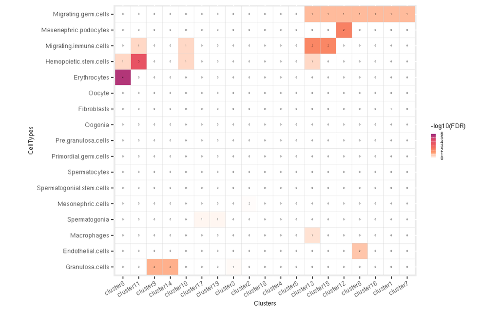

```r
marker_test_genes =
  scatter_markers_top100 %>%
  select(Gene, cluster) %>%
  mutate(cluster = paste0("cluster", cluster))

chung_davidson_cell_type_markers = chung_davidson_markers %>%
  select(Gene, CellType)

plot_marker_overlap_heatmap(
  known_markers  = chung_davidson_cell_type_markers,
  test_genes     = marker_test_genes,
  background_n   = length(merged.sce),
  gene_description = gene_description,
  overlaps_file  = paste0(results_dir, "/scatter_cluster_marker_gene_overlaps.csv"),
  pvals_file     = paste0(results_dir, "/scatter_cluster_marker_overlap_pvalues.csv"),
  plot_file      = paste0(results_dir, "/scatter_cluster_overlap_heatmap.png")
)
```

## Gene ontology of top 100 cluster enriched genes

**Columns:** `GOID`, `GOName`, `nGOTermGenes`, `Clusters`, `nClusterEnrichedGenes`, `nSharedGenes`, `Pval`, `FDR`

- Overlap p-values: `scatter_cluster_marker_gene_GO_overlap_pvalues.csv`
- Overlapping genes: `scatter_cluster_marker_gene_GO_overlaps.csv`

```r
gaf = read.delim("/mnt/research/bioinformaticsCore/shared/Genomes/Petromyzon_marinus/GCF_010993605.1_kPetMar1.pri_gene_ontology.gaf",
                 header = FALSE, comment = "!")

gaf <- gaf %>%
  filter(!grepl("NOT", V4)) %>%
  dplyr::select(V3, V5) %>%
  dplyr::rename(GOID = "V5", Gene = "V3") %>%
  distinct()

keep_go = gaf %>%
  group_by(GOID) %>% tally() %>%
  filter(n > 10, n < 200) %>%
  pull(GOID)

gaf = gaf %>% filter(GOID %in% keep_go)

go_names = read.delim("/mnt/research/bioinformaticsCore/shared/Genomes/Petromyzon_marinus/GOs_names.txt",
                      header = FALSE)
colnames(go_names) = c("GOID", "GOName")

scores = run_go_enrichment(
  gaf             = gaf,
  gene_description = gene_description,
  go_names        = go_names,
  test_genes      = marker_test_genes,
  background_n    = length(merged.cds),
  overlaps_file   = paste0(results_dir, "/scatter_cluster_marker_gene_GO_overlaps.csv"),
  pvals_file      = paste0(results_dir, "/scatter_cluster_marker_gene_GO_overlap_pvalues.csv"),
  pval_filter     = 0.01
)

datatable(scores, filter = "top", rownames = FALSE)
```

| GOID | GOName | nGOTermGenes | Clusters | nClusterEnrichedGenes | nSharedGenes | Pval | FDR |
| --- | --- | --- | --- | --- | --- | --- | --- |
| GO:0000027 | ribosomal large subunit assembly | 16 | cluster10 | 100 | 2 | 0.002361690308546165 | 0.1670895893296412 |
| GO:0000027 | ribosomal large subunit assembly | 16 | cluster13 | 100 | 2 | 0.002361690308546165 | 0.1670895893296412 |
| GO:0000028 | ribosomal small subunit assembly | 15 | cluster10 | 100 | 7 | 2.043744351559303e-13 | 2.478769934962641e-11 |
| GO:0000028 | ribosomal small subunit assembly | 15 | cluster13 | 100 | 4 | 5.309774988960386e-07 | 6.439998522324811e-05 |
| GO:0000028 | ribosomal small subunit assembly | 15 | cluster18 | 100 | 4 | 5.309774988960386e-07 | 6.439998522324811e-05 |
| GO:0000079 | regulation of cyclin-dependent protein serine/threonine kinase activity | 25 | cluster14 | 100 | 2 | 0.005748986011303322 | 0.1877265047537123 |
| GO:0000079 | regulation of cyclin-dependent protein serine/threonine kinase activity | 25 | cluster15 | 100 | 2 | 0.005748986011303322 | 0.2324232915998343 |
| GO:0000079 | regulation of cyclin-dependent protein serine/threonine kinase activity | 25 | cluster16 | 100 | 2 | 0.005748986011303322 | 0.1952355649438608 |
| GO:0000226 | microtubule cytoskeleton organization | 71 | cluster14 | 100 | 7 | 3.431368993290293e-08 | 9.71077425101153e-06 |
| GO:0000226 | microtubule cytoskeleton organization | 71 | cluster15 | 100 | 5 | 1.813717915325596e-05 | 0.002074390397409099 |

[output cut: 158 more lines]

## Plot known cell-type markers

Early germ cell markers.

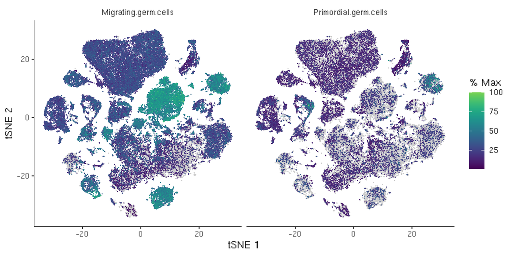

```r
rowData(merged.cds)$gene_short_name = row.names(merged.cds)

unique_markers = chung_davidson_markers %>%
  group_by(Gene) %>% tally() %>%
  filter(n == 1) %>%
  pull(Gene)

genes_for_plot = chung_davidson_markers %>%
  select(Gene, CellType) %>%
  filter(Gene %in% unique_markers)

plot_cells(merged.cds, reduction_method = "tSNE",
           genes = genes_for_plot %>%
             filter(CellType %in% c("Migrating.germ.cells", "Primordial.germ.cells")))
```

Female cell markers.

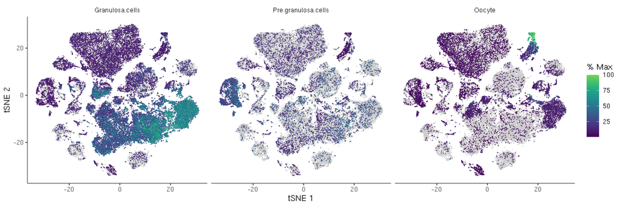

```r
plot_cells(merged.cds, reduction_method = "tSNE",
           genes = genes_for_plot %>%
             filter(CellType %in% c("Oogonia", "Oocyte",
                                    "Granulosa.cells", "Pre.granulosa.cells")),
           show_trajectory_graph = FALSE,
           label_cell_groups     = FALSE,
           label_leaves          = FALSE,
           label_branch_points   = FALSE)
```

Male cell markers.

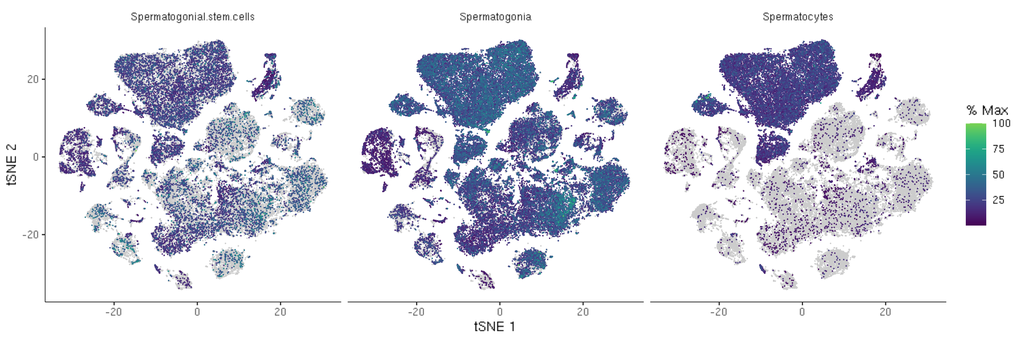

```r
plot_cells(merged.cds, reduction_method = "tSNE",
           genes = genes_for_plot %>%
             filter(CellType %in% c("Spermatocytes", "Spermatogonia",
                                    "Spermatogonial.stem.cells")),
           show_trajectory_graph = FALSE,
           label_cell_groups     = FALSE,
           label_leaves          = FALSE,
           label_branch_points   = FALSE)
```

## Annotations

```r
anno = c(
  "1. Fibroblasts (migrating)",
  "2. Mesonephric cells",
  "3. Granulosa cells (migrating)",
  "4. Granulosa cells",
  "5. Oogonia/Oocytes",
  "6. Endothelial cells",
  "7. Primordial germ cells (migrating)",
  "8. Erythrocytes",
  "9. Pre-granulosa cells (migrating)",
  "10. Leukocytes",
  "11. Hemopoietic stem cells",
  "12. Podocytes",
  "13. Macrophages",
  "14. Pre-granulosa cells (mitotic)",
  "15. Immune cells (migrating, mitotic)",
  "16. Spermatocytes (cytokinetic)",
  "17. Male germ cells (migrating)",
  "18. Spermatocytes (apoptotic)",
  "19. Spermatocytes (GPCR-activated)"
)
```

1. Fibroblasts (migrating)
2. Mesonephric cells
3. Granulosa cells (migrating)
4. Granulosa cells
5. Oogonia/Oocytes
6. Endothelial cells
7. Primordial germ cells (migrating)
8. Erythrocytes
9. Pre-granulosa cells (migrating)
10. Leukocytes
11. Hemopoietic stem cells
12. Podocytes
13. Macrophages
14. Pre-granulosa cells (mitotic)
15. Immune cells (migrating, mitotic)
16. Spermatocytes (cytokinetic)
17. Male germ cells (migrating)
18. Spermatocytes (apoptotic)
19. Spermatocytes (GPCR-activated)

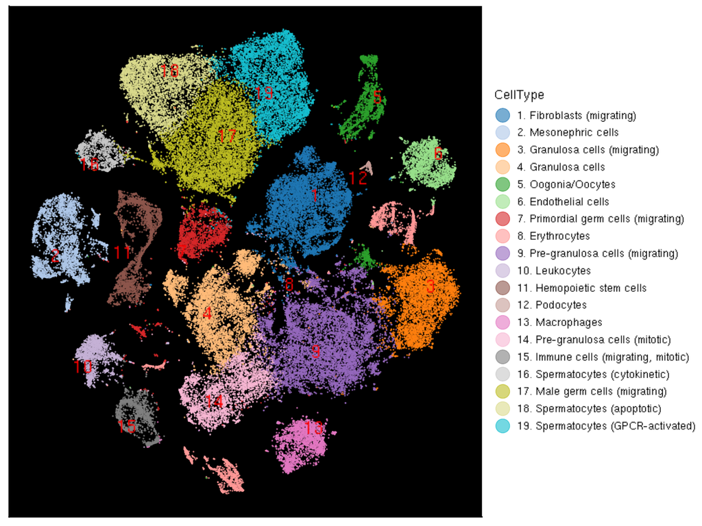

```r
ct = anno[colData(merged.sce)$label]
merged.sce$CellType = ct
merged.sce$CellType = factor(merged.sce$CellType, levels = anno)

plotTSNE(merged.sce, colour_by = "CellType", text_by = "label",
         text_colour = "red", point_size = .05) +
  guides(color = guide_legend(override.aes = list(size = 5))) +
  theme(panel.background = element_rect(fill = "black"),
        axis.title = element_blank(),
        axis.text  = element_blank(),
        axis.ticks = element_blank())
```

```r
ggsave(file = paste0(results_dir, "/all_cells_tsne_black.png"), height = 6, width = 8)
```

## Bubble plots per cell type

```r
nested_df   <- chung_davidson_markers %>% group_by(CellType) %>% tidyr::nest()
list_of_dfs <- nested_df$data
names(list_of_dfs) <- nested_df$CellType
names(list_of_dfs)  = gsub("\\(", "", names(list_of_dfs))

file_names = gsub(" ", "_", names(list_of_dfs))
file_names = paste0(file_names, "_all_cell_clusters")

plot.sce = combined.sce
colData(plot.sce) <- colData(merged.sce)

ct = anno[colData(plot.sce)$label]
plot.sce$CellType = ct
plot.sce$CellType = factor(plot.sce$CellType, levels = anno)
plot.sce$cluster  = plot.sce$label

plot_dir = paste0(results_dir, "/all_cell_bubble")
if (!dir.exists(plot_dir)) dir.create(plot_dir)

scatter_markers_df = read.csv(
  file    = paste0(results_dir, "/scatter_cluster_marker_genes.csv"),
  row.names = 1)

cluster_index              = as.numeric(gsub("cluster_", "", scatter_markers_df$cluster))
scatter_markers_df$CellType = anno[cluster_index]

markers = scatter_markers_df %>%
  select(WangGeneID, CellType, FDR, summary.logFC) %>%
  dplyr::rename(Gene = "WangGeneID")

for (i in 1:length(list_of_dfs)) {
  plot_marker_bubbles(
    sce              = plot.sce,
    markers          = markers,
    gene_description = gene_description,
    cell_type_name   = names(list_of_dfs)[i],
    cell_type_genes  = list_of_dfs[[i]],
    anno             = anno,
    results_dir      = plot_dir,
    file_name        = file_names[i]
  )
}
```